# Micro I Notes

Parker Howell

Last Updated: 2024-07-09

# 1 Preference

### 1.0.1 Def “binary relation”

A binary relation $R$ on $X$ is a subset of $X \times X$.

The ordered pair $(x,y) \in R$ means $x$ is (weakly) preferred to $y$.

### 1.0.2 Remark “binary relation notation”

We use $\succsim$ to denote $R$ but all these methods are the same thing:
$$(x,y) \iff xRy \iff x \succsim
y$$

### 1.0.3 Def “attributes of binary relations”

A binary relation $\succsim$ is

1. complete if for all $x,y\in X$ either $x \succsim y$ or $y \succsim x$
2. transitive if for all $x,y,z\in X, [x \succsim y, y \succsim z] \Rightarrow x \succsim y$
3. reflexive if for all $x \in X, x \succsim x$
4. symmetric if for all $x,y\in X, x \succsim y \iff y \succsim x$
5. irreflexive if for all $x \in X, x \not\succsim x$
6. asymmetric if for all $x,y\in X, x \succsim y \Rightarrow y \not\succsim x$
7. antisymmetric if for all $x,y \in X, [x \succsim y$ AND $x\neq y] \Rightarrow y \not\succsim x$
   - i.e., $xRy$ and $yRx$ implies $x=y$

### 1.0.4 “Lemma 1 (handout) rational implies”

A. $\succsim$ rational $\Rightarrow \succ$ asymmetric and transitive B. $\succsim$ rational $\Rightarrow \sim$ symmetric and transitive C. $\succsim$ rational $\Rightarrow x \succsim y \succsim z$ and either $x\not\sim y$ or $y \not\sim z$ implies $x\succ z$

### 1.0.5 Def “rational”

A binary relation $\succsim$ is *rational* if it is complete and transitive

# 2 Choice

### 2.0.1 Def “choice function”

A function $c: \mathcal{B} \rightarrow \mathcal{P}(X)$ is called a *choice function* if for all $A \in \mathcal{B}, c(A) \subseteq A$.

1. If $c$ is a choice function, then $c(A) \neq \emptyset, \forall A \in \mathcal{B}$
2. $|c(A)| \geq 1$

### 2.0.2 Def “choice structure”

The pair $(\mathcal{B}, c)$ is called a *choice structure*.

### 2.0.3 Def “WARP”

Weak Axiom of Revealed Preference. The following are equivalent for all $A, B \in \mathcal{B}$:

- $c(A) \cap B \neq \emptyset \Rightarrow c(B) \cap A \subseteq c(A)$
- $[c(A) \cap B \neq \emptyset \text{ AND } c(B) \cap A \neq \emptyset] \Rightarrow [c(A) \cap B \subseteq c(B) \text{ AND } c(B) \cap A \subseteq c(A)]$
- $x, y \in A \cap B, x \in c(A), y \in c(B) \Rightarrow x \in c(B), y \in c(A)$
- Sen’s $\alpha$ and $\beta$ both hold

### 2.0.4 Def Sen’s $\alpha$ and $\beta$

For all $A, B \in \mathcal{B}$:

1. Sen’s $\alpha$: If $x \in B \subseteq A$ and $x \in c(A)$ then $x\in c(B)$
2. Sen’s $\beta$: If $x,y \in c(B), B \subseteq A$ and $y \in c(A)$ then $x\in c(A)$

### 2.0.5 Prop 1 “WARP $\iff \alpha$ and $\beta$”

### 2.0.6 Term “single-valued”

We say $c$ is single-valued if $\forall A \in \mathcal{B}, |c(A)| = 1$

### 2.0.7 Prop 2 “$\alpha$ and single-valued $\Rightarrow$ WARP”

If $(\mathcal{P}(X), c)$ satisfies $\alpha$ and $c$ is single-valued, then it satisfies WARP.

# 3 Choice and Preference

### 3.0.1 Def “$c_\succsim$”

For any binary relation $\succsim$ define
$$c_\succsim(A) = \{x \in A: x
\succsim y, \forall y \in A\}, \forall A \in \mathcal{P}(X)$$

### 3.0.2 Def “$\succsim_c$”

For a choice structure $(\mathcal{P}(X), c)$ define a binary relation $\succsim_c$ such that
$$x \succsim_c y \iff x \in c(\{x,y\})$$

### 3.0.3 Prop “satisfies WARP $\iff \succsim$ rational”

If $\succsim$ is a binary relation on a finite set $X$ then $(\mathcal{P}(X), c_\succsim)$ is a choice structure that satisfies WARP if and only if $\succsim$ is rational.

### 3.0.4 Prop “WARP $\Rightarrow c=c_\succsim$”

If $(\mathcal{P}, c)$ is a choice structure that satisfies WARP then there exists a unique rational binary relation $\succsim$ such that $c=c_\succsim$ (i.e., for all $A \in \mathcal{P}, c(A) = c_\succsim (A)$).

# 4 Utility

### 4.0.1 Def “utility function”

A function $U: X \rightarrow \mathbb{R}$ represents $\succsim$ if and only if, for all $x, y \in X$
$$x
\succsim y \iff U(x) \geq U(y).$$

### 4.0.2 Prop “$U$ represents $\succsim \Rightarrow$ rational”

If $U: X \rightarrow \mathbb{R}$ represents $\succsim$, then $\succsim$ is rational.

> Note: this proposition does NOT require finiteness!

### 4.0.3 Prop “$X$ finite + $\succsim$ rational $\Rightarrow \exists U$

If $X$ is finite and $\succsim$ is rational then there exists $U: X \rightarrow \mathbb{R}$ that represents $\succsim$.

### 4.0.4 Prop “$V \iff \phi$ and $\phi$ strictly increasing”

Suppose $U: X \rightarrow \mathbb{R}$ represents $\succsim$. Then $V: X \rightarrow \mathbb{R}$ represents $\succsim$ if and only if there exists $\phi: U(X) \rightarrow V(X)$ such that $V = \phi \circ U$ and $\phi$ is strictly increasing.

# 5 Expected Utility

### 5.0.1 Def “lottery”

Suppose $X$ is a non-empty and finite set of prizes (consequences). Then a *lottery*, $p$ is a probability distribution over $X$:
$$p:
X \rightarrow [0,1], \text{ such that } \sum_{x\in X} p(x) =
1.$$

We denote $\mathcal{L}$ as the set of all lotteries.

### 5.0.2 Term “degenerate lottery”

If $p(x)=1$ for some $x \in X$ then we write $\delta_x$.

### 5.0.3 Remark: $\mathcal{L}$ is the set of alternatives, and unlike $X$ is infinite!

### 5.0.4 Def “vNM expected utility function/utility index”

$U: \mathcal{L} \rightarrow \mathbb{R}$ is an expected utility function if there exists $u: X \rightarrow \mathbb{R}$ such that $U(p) = \sum_{x \in X} u(x)p(x), \forall p \in \mathcal{L}$.

Called a “von Neumann–Morgenstern utility index” or a “Bernoulli index.”

### 5.0.5 Def “Mixture operation”

For all $p, q \in \mathcal{L}, \alpha \in [0,1]$:

- let $\alpha p + (1-\alpha)q$ denote a lottery $r\in \mathcal{L}$ such that for all $x\in X, r(x) = \alpha p(x) + (1-\alpha)q(x)$.

### 5.0.6 Def “expected utility representation”

$\succsim$ on $\mathcal{L}$ has an expected utility representation if there exists $u: X \rightarrow \mathbb{R}$ such that for $p,q \in \mathcal{L}$
$$p \succsim q \iff U(p) = \sum_{x\in X} p(x)u(x)
\geq U(q) = \sum_{x\in X} q(x)u(x)$$

### 5.0.7 Def “linear function”

A function $U: \mathcal{L} \rightarrow \mathbb{R}$ is *linear* if for all $\alpha \in [0,1]$ and $p,q \in \mathcal{L}$:
$$U(\alpha p + (1-\alpha)q) = \alpha U(p) +
(1-\alpha) U(q).$$

### 5.0.8 Lemma “linear $\iff U$ is an expected utility function”

A function $U: \mathcal{L} \rightarrow \mathbb{R}$ is *linear* if and only if $U$ is an expected utility function.

### 5.0.9 Def “vNM Axioms”

The von Neumann–Morgenstern axioms are:

- A1. (Rationality): $\succsim$ is complete and transitive.
- A2. (Independence): For all $p,q,r \in \mathcal{L}, \alpha \in (0,1)$ we have $[p \succ q] \Rightarrow [\alpha p + (1-\alpha)r \succ \alpha q + (1-\alpha)r]$.
- A3. (Continuity): For all $p, q, r \in \mathcal{L}$, if $p \succ q \succ r$ then there exists $\alpha, \beta \in (0,1)$ such that $\alpha p + (1- \alpha) r \succ q$ and $q \succ \beta p + (1-\beta) r$.
- We don’t use A2* in this class, but some literature uses it:
  - A2*. (Independence, strengthened): $[p \succsim q] \iff [\alpha p + (1-\alpha) r \succsim \alpha q + (1-\alpha)r]$

### 5.0.10 Lemma “applying vNM Axioms”

Suppose $\succsim$ satisfies A1, A2, and A3 of vNM axioms.

1. $\forall \alpha \in (0,1), p,q \in \mathcal{L}$:
   1. $p \succ q \Rightarrow p \succ \alpha p + (1 - \alpha) q \succ q$
   2. $p \sim q \Rightarrow p \sim \alpha p + (1 - \alpha) q \sim q$
2. $p \succ q, 1 \geq \alpha > \beta \geq 0 \Rightarrow \alpha p + (1-\alpha)q \succ \beta p + (1-\beta)q$
3. $p \sim q, \alpha \in (0,1) \Rightarrow \alpha p + (1-\alpha)r \sim \alpha q + (1-\alpha)r$
4. $p \succsim q, r \succsim s, \alpha \in (0,1) \Rightarrow \alpha p + (1-\alpha)r \succsim \alpha q + (1-\alpha)s$

### 5.0.11 Thm “A1-A3 $\iff$ EU representation”

Suppose $X$ is finite and $\succsim$ is a binary relation on $\mathcal{L}$. Then
$$[\succsim \text{ satisfies A1, A2, and A3 }] \iff
\succsim \text{ has an Expected Utility representation.}$$

### 5.0.12 Thm “$V$ linear representation $\iff V(p) = aU(p)+b$”

Suppose $U$ is a linear representation of $\succsim$, and $V: \mathcal{L}\rightarrow \mathbb{R}$ is a linear function. Then
$$[V \text{ is a linear representation of }
\succsim] \iff [\exists a>0, b\in\mathbb{R} \text{ such that }
V(p)=aU(p) + b, \forall p \in \mathcal{L}]$$

#### 5.0.12.1 Term “affine”

Basically a line, but the intercept doesn’t have to be zero. “A function composed of a linear function and a constant and its graph is a straight line.”

### 5.0.13 Def “simple lottery”

$p: X \rightarrow \mathbb{R}$ is a *simple lottery* if

1. $\{x\in X: p(x)>0\}$ is finite
2. $\displaystyle \sum_{\{x\in X: p(x)>0\}} p(x) = 1$

### 5.0.14 Def “simple improvement”

For all (simple) lotteries $p,q \in \mathcal{L}$, $p$ is a simple improvement of $q$ if there exists $\lambda \in (0,1), m, m' \in X, m>m';, r \in \mathcal{L}$ such that
$$p = \lambda \delta_m + (1-\lambda)r \text{ and }
q = \lambda \delta_m' + (1-\lambda)r.$$

### 5.0.15 Def “FOSD”

For $p, q \in \mathcal{L}$, $p$ first-order stochastically dominates (FOSD) $q$ if

1. $p \neq q$, and
2. $F_p(x) \leq F_q(x), \forall x \in X$

> caution: CDF of $p$ SMALLER than CDF of $q$ means $p$ dominates $q$, not the other way around

### 5.0.16 Fact “$p$ FOSD $q \iff p$ is a complex improvement of $q$”

### 5.0.17 Thm “EU representation means $p$ FOSD $q \Rightarrow p \succ q$ and $u$ strictly increasing”

Suppose $\succsim$ has an expected utility representation. Then the following are equivalent:

1. $p$ FOSD $q \Rightarrow p \succ q$
2. $p$ is a simple improvement of $q \Rightarrow p \succ q$
3. Every EU representation of $\succsim$ has a strictly increasing utility index ($U(p) = \sum_{x \in supp(p)} \underline{u(x)}p(x)$)

### 5.0.18 Def “Betweenness Axiom”

$$\forall p,q \in \mathcal{L}, \lambda \in
(0,1):$$
$$p \sim q \Rightarrow
\lambda p + (1-\lambda)q \sim p$$

### 5.0.19 Def “Allais paradox”

Individuals prefer certainty over a risky outcome even if this defies the expected utility axiom

## 5.1 Risk Attitudes

### 5.1.1 Lemma

Suppose $\succsim$ has an expected utility representation with a strictly increasing and continuous index $u$. Then $\forall p \in \mathcal{L}, \exists$ unique $CE(p)\in X$ such that $p \sim \delta_{CE(p)}$. In this case, $CE(p)$ is the *certainty equivalent* of $p$.
$$CE(p) = u^{-1}(U(p)) = u^{-1}(\sum_{x\in
supp(p)}u(x)p(x))\in X \iff u(CE(p))=U(p)$$

### 5.1.2 Def “risk attitudes”

Let $\bar{p} = \sum_{x \in supp(p)} p(x)x$ be the expected value of $p$. Then $p$ is riskier than $\delta_{\bar{p}}$. For all $p \in \mathcal{L}$, $\succsim$ is

1. *risk averse* if $\delta_{\bar{p}} \succsim p$
2. *risk neutral* if $\delta_{\bar{p}} \sim p$
3. *risk seeking* if $p \succsim \delta_{\bar{p}}$

### 5.1.3 Def “simple Mean-Preserving Spread (MPS)”

Say $\hat{p} = \lambda p + (1-\lambda)r$ is a simple mean-preserving spread of $\hat{q} = \lambda \delta_{\bar{p}} + (1-\lambda)r$. $\hat{p}$ is riskier than $\hat{q}$.

### 5.1.4 Thm “risk-averse $\iff u$ concave $\iff$ MPS”

$\succsim$ has an EU representation such that its utility index, $u$, is strictly increasing and continuous. Then the following are equivalent:

1. $\succsim$ is risk-averse / -seeking / -neutral
2. $[p$ is a simple MPS of $q] \Rightarrow q \succsim p$
3. $u$ is concave / convex / affine

### 5.1.5 Def “more risk averse”

$\succsim_1$ is more risk averse than $\succsim_2$ if for all $m\in X, p \in \mathcal{L}$ we have
$$\delta_m \succsim_2 p \Rightarrow \delta_m
\succsim_1 p.$$

#### 5.1.5.1 Term “Absolute risk aversion”

Call $-\frac{u_1''}{u_2'}$ Arrow-Pratt’s measure of absolute risk aversion (ARA).

### 5.1.6 Thm “more risk averse $\iff$ concave composition”

$\succsim_1, \succsim_2$ have an EU representation with $u_1, u_2$ strictly increasing and smooth. Then the following are equivalent:

1. $\succsim_1$ is (always) more risk averse than $\succsim_2$.
2. there exists a concave and strictly increasing function $f: u_2(X) \rightarrow u_1(X)$ such that $u_1 = f \circ u_2 = f(u_2(x)), \forall x \in X$
3. $ARA_{u_1} \geq ARA_{u_2}$

#### 5.1.6.1 Term “smooth”

Twice continuously differentiable

### 5.1.7 Def “CARA”

$$ARA = -\frac{u''(x)}{u'(x)}
= a (\text{const} \in \mathbb{R})$$
Constant Absolute Risk Aversion (CARA) means risk attitude does not depend on the initial wealth level.

### 5.1.8 Def “functional form for CARA”

$$u(x) = \begin{cases} \frac{1-e^{-ax}}{a}
\text{ if } a \neq 0 \\ x \text{ if } a=0\end{cases}$$

- $a>0 \Rightarrow$ risk-averse
- $a=0 \Rightarrow$ risk-neutral
- $a<0 \Rightarrow$ risk-seeking

> Can compare the “a-level” of individuals to see who is more risk averse (e.g., $a_1 > a_2 \Rightarrow$ person 1 more risk-averse)

### 5.1.9 Def “CRRA”

$$RRA = -x\frac{u''(x)}{u'(x)}
= \text{const} = r$$

> person is risk-neutral when $u(x) = x$.

# 6 Demand Theory

### 6.0.1 Def “Well-behaved” preference

1. Monotone
   $$[x_i \geq y_i, \forall
   i]\Rightarrow[x \succsim y]$$
2. Strongly Monotone
   $$[x_i \geq y_i,
   \forall i \text{ and } x\neq y]\Rightarrow[x \succ y]$$
3. MWG Monotone
   $$[x_i > y_i, \forall
   i]\Rightarrow[x \succ y]$$
4. Locally non-satiated
   $$\forall x \in X,
   \forall \varepsilon > 0, \exists y \in B_\varepsilon(x) \text{ such
   that } y \succ x$$
5. Continuity $x^{(m)} \rightarrow x$ and $y^{(m)} \rightarrow y, \forall m \geq 1$ and $x^{(m)} \succsim y^{(m)} \Rightarrow x \succsim y$

### 6.0.2 Def “convex relation”

For all $x, y \in X$ and for all $\alpha \in (0,1)$:

- $\succsim$ is *convex* if
  $$x \succsim y \Rightarrow \alpha x +
  (1-\alpha)y \succsim y$$
- $\succsim$ is *strictly convex* if
  $$x \succsim y, x \neq y
  \Rightarrow \alpha x + (1-\alpha)y \succ y$$

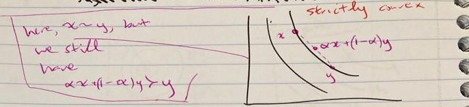

### 6.0.3 Claim “$\succsim$ is rational $\not\Rightarrow \succsim$ has a utility representation”

### 6.0.4 Term “lexicographic preferences”

1. $\succsim$ is rational
2. $\succsim$ is not continuous
3. $\succsim$ does not have a utility representation

### 6.0.5 Def “economic preference / well-behaved preference”

A binary relation $\succsim$ is an *economic preference* (well-behaved preference) if it is 1. rational, 2. continuous, 3. monotone, and 4. locally non-satiated.

### 6.0.6 Thm “economic preference $\Rightarrow$ represented by continuous $U$”

$\succsim$ is an economic preference $\Rightarrow \succsim$ can be represented by a continuous utility function $U$.

### 6.0.7 Remark $U$ is also monotone and MWG monotone, but not strong

# 7 Demand

#### 7.0.0.1 Term “price vector”

$P \in \mathbb{R}^n_{++}$. $p \in P: p = (p_1, ..., p_n), p_i > 0 \forall i$

#### 7.0.0.2 Term “Budget constraint”

$$B(p, m) = \{\vec{x} \in X: p \cdot
\vec{x} = \sum^n_{i=1} p_i \cdot x_i \leq m\}, \forall p \in P, m \geq
0.$$
$B(p, m)$ is compact, non-empty (and convex, but that isn’t important for now.)

### 7.0.1 Thm “economic preference $\Rightarrow$ solution exists”

If $\succsim$ is an economic preference then $\forall p, m\geq 0, \exists x^* \in B(p,m)$ such that

1. $x^* \succsim y, \forall y \in B(p,m)$ and
2. $p \cdot x^* = m$.

### 7.0.2 Def “demand”

$$D: \mathcal{B} \rightarrow
\mathcal{P}(X) \text{ such that } D(B(p,m)) = \{x^*\in B(p,m): x^*
\succsim y \forall y \in B(p,m)\}$$

Where $\mathcal{B} = \{B(p,m): p \in P, m\geq 0\} \subsetneq \mathcal{P}(X).$ We can verify that $(\mathcal{B}, D)$ is a choice structure.

### 7.0.3 Def “demand function”

If $D(B(p,m))$ is always a singleton we can define:
$$x: P \times
\mathbb{R}_+ \rightarrow X$$
such that $x(p,m)$ is the only element of $D(B(p,m))$. We call $x(\cdot)$ the demand function.

### 7.0.4 Thm “strictly convex $\Rightarrow$ demand fn well-defined”

If $\succsim$ is a strictly convex economic preference then $x(\cdot)$ is a well-defined and continuous function.

### 7.0.5 Def “indirect utility function”

$V: P\times \mathbb{R}_+ \rightarrow \mathbb{R}$ such that $V(p,m) = U(x(p,m))$.

### 7.0.6 Def “neoclassical utility function”

$U: X \rightarrow \mathbb{R}$ is a *neoclassical utility function* if $U$

1. is continuous, and
2. represents a strictly convex economic preference.

### 7.0.7 Thm “neoclassical $U \Rightarrow$ properties of $V$”

Suppose $U$ is neoclassical and $V$ is the associated indirect utility function. Then,

1. $V$ is continuous,
2. $V$ is strictly increasing in $m$,
3. $V$ is quasiconvex ($V(p,m) \geq V(p',m') \Rightarrow V(p,m) \geq V(\alpha p + (1-\alpha)p', \alpha m + (1-\alpha)m'$), and
4. $V$ is homogeneous of degree 0 ($V(p,m) = V(\lambda p, \lambda m)$)

## 7.1 Hicksian Demand

### 7.1.1 Thm “neoclassical $\Rightarrow$ unique minimization solution”

Suppose $U$ is neoclassical. Then for all $p\in P, u\in U(X), \exists$ unique $x^*\in X$ such that

1. $U(x^*) = u$ and
2. $\forall x \in X, x \neq x^*: U(x) \geq u \Rightarrow p\cdot x > p \cdot x^*$

### 7.1.2 Def “Hicksian demand function

Let $x^h(p,u)$ denote $x^* \forall p \in P, u \in U(X)$. Then $x^h: P \times U(X) \rightarrow X$ is called the *Hicksian demand function*.

### 7.1.3 Def “expenditure function”

Define the *expenditure function*, $e: P \times U(X) \rightarrow X$ such that $\forall p \in P, u \in U(X):$
$$e(p,u)= p \cdot x^h(p,u).$$

### 7.1.4 Thm “duality theorem”

Suppose $U$ is neoclassical. Then

1. $e(p, V(p,m)) = m$
2. $V(p,e(p,u)) = u$
3. $x(p,e(p,u)) = x^h(p,u)$
4. $x^h(p, V(p,m)) = x(p,m)$.

Three important results:

### 7.1.5 Thm “relating $e(\cdot)$ and $x^h(\cdot)$”

Suppose $U$ is neoclassical. Then

1. $e(\cdot)$ is continuous,
2. $e(\cdot)$ is strictly increasing in $u$ and non-decreasing in $p_i$,
3. $e(\cdot)$ is concave in $p$ for fixed $u \in U(X)$,
4. $e(\lambda p, u) = \lambda e(p,u), \forall \lambda>0$, and
5. $\frac{\partial}{\partial p_i} e(p,u) = x^h_i(p,u), \forall i = 1, ..., n.$

### 7.1.6 Thm “relating $x(\cdot)$ and $V(\cdot)$ (Roy’s identity)”

Suppose $U$ is neoclassical, $V(p,m)$ is differentiable at $(p,m)$ and $x(p,m)$, is in the interior of $X$. Then
$$x_i(p,m) = -\frac{\frac{\partial }{\partial
p_i}V(p,m)}{\frac{\partial }{\partial m}V(p,m)}$$

### 7.1.7 Lemma “Shephard’s Lemma”

Use this to go from expenditure function ($e(\cdot)$) to Hicksian demand ($x^h$):

$$x^h_i(\mathbf{p},u) = \frac{\partial
e(\mathbf{p}, u)}{\partial p_i}$$
This is the counterpart to Roy’s identity, just on the Hickisan side (and simpler).

### 7.1.8 Thm “relating $x(\cdot)$ and $x^h(\cdot)$ (Slutsky equation)”

Suppose $U$ is neoclassical, $x(\cdot)$ is continuously differentiable, and $x(p,m)$ is in the interior of $X$. Then
$$\frac{\partial x_i^h}{\partial p_k} (p, V(p,m)) =
\underbrace{\frac{\partial x_i}{\partial p_k} (p,
m)}_{\text{substitution effect}} + \underbrace{\frac{\partial
x_i}{\partial m} (p, m) x_k(p,m)}_{\text{income effect}}, \forall i, k
\in \{1, ... ,n\}$$

# 8 Misc

### 8.0.1 “Utility Maximization”

Utility is maximized when
$$\frac{MU_x}{p_x} = \frac{MU_y}{p_y}$$